# Project 1 - CS4821 Data Mining

Nishanth Gandhidoss

23 January 2017

## Question 1

(4 points) From your reading of Ch. 1 of the text book, in your own words, what is the difference between classification and regression? How are they similar?

### **Classification and Regression**

- Classification is a predictive methodology used to distinguish a sample of observations to which classes or label they belong to. It is used generally predict categorical labels which are predominantly ordered or unordered.
- Regression is also a prediction technique which is used to identify the correlation or trend relationship between dependent and independent variables. Generally, it best works for and most often used for continuous data.
- Classification and regression, both are supervised learning techniques where the outcomes are used to build the model. And the model used to make the prediction for other datasets.

## Question 2

### Census Data

Consider the [Census Income](http://archive.ics.uci.edu/ml/datasets/Census+Income) data set available at the UCI ML archive. Specifically, you will be interested in the adult.data file which contains the data and adult.names files which contains documentation about the data.

You should explore the files a bit in a text editor to understand the format. Then load the data for you analysis, the first samples of the data set should be:

39, State-gov, 77516, Bachelors, 13, Never-married, Adm-clerical, Not-in-family, White, Male, 2174, 0, 40, United-States, <=50K

The variables are made up of different types: numeric, nominal, etc. Answer the following questions:

#### Question 2 (a)

(14 points) **Variable Definitions**

For each variable (column of the data set) excluding the final target variable (last column), write a clear 1-sentence description of what the variable is, i.e., what information does it describe and how is it defined collected.

To answer this question, you may have to do a bit of reading and research into this data set. If you can not find a clear explanation of what a variable is and how it is defined say so.

For example, the variable “Age” could be described as, “AGE is the age of an individual as reported by that person for the 1990 census; the value is reported in integer units of years.”

```r
# Reading the data
destfile <- "data/census_data.csv"

# checking whether the file already exists or not
if(!file.exists(destfile)) {
    census_data <- read.csv(url("http://archive.ics.uci.edu/ml/machine-learning-databases/adult/adult.data"), col.names = c("age", "workclass", "fnlwgt", "education", "education-num", "marital-status", "occupation", "relationship", "race", "sex", "capital-gain", "capital-loss", "hours-per-week", "native-country", "salary"), header = F)
    write.csv(census_data, file = "data/census_data.csv")
} else {
    census_data <- read.csv("data/census_data.csv", header = T)
}
```

**Age**: age of the person reported by each individual recorded for 1990 census in integer units of years as a continuous variable.

**Workclass**: represents the various category of what kind of work a particular individual is doing at the time of taking the census. It is a categorical with Private, Self-emp-not-inc, Self-emp-inc, Federal-gov, Local-gov, State-gov, Without-pay and Never-worked as labels.

**fnlwgt**: Final sampling weight is a continuous variable that is the inverse of sampling fraction adjusted for non-response and over or under sampling of particular groups.

**Education**: categorical variable describing the maximum qualification of an individual. Bachelors, Some-college, 11th, HS-grad, Prof-school, Assoc-acdm, Assoc-voc, 9th, 7th-8th, 12th, Masters, 1st-4th, 10th, Doctorate, 5th-6th, Preschool.

**Education-num**: It is an column of integers represents each and every category of the education column.

**Marital-status**: categorical variable tells what is the marital status of the individual. Married-civ-spouse, Divorced, Never-married, Separated, Widowed, Married-spouse-absent, Married-AF-spouse.

**Occupation**: categorical variable which tells what is kind of work they were doing at time of census. Tech-support, Craft-repair, Other-service, Sales, Exec-managerial, Prof-specialty, Handlers-cleaners, Machine-op-inspct, Adm-clerical, Farming-fishing, Transport-moving, Priv-house-serv, Protective-serv, Armed-Forces.

**Relationship**: current relationship status as a categorical variable. Wife, Own-child, Husband, Not-in-family, Other-relative, Unmarried.

**Race**: categorical variable which defines the race of the individual pesrons who gave the reply for the census study. White, Asian-Pac-Islander, Amer-Indian-Eskimo, Other, Black.

**Sex**: categorical variable which describes the gender of the each observation on the census data. Female, Male.

**capital-gain**: is a continuous variable which describes an increase in the value of a capital asset that gives it a higher worth than the purchase price.

**hours-per-week**: continuous variable which describes how many hours a person is working per week.

**native-country**: categorical variable which says the native country of the each individuals. United-States, Cambodia, England, Puerto-Rico, Canada, Germany, Outlying-US(Guam-USVI-etc), India, Japan, Greece, South, China, Cuba, Iran, Honduras, Philippines, Italy, Poland, Jamaica, Vietnam, Mexico, Portugal, Ireland, France, Dominican-Republic, Laos, Ecuador, Taiwan, Haiti, Columbia, Hungary, Guatemala, Nicaragua, Scotland, Thailand, Yugoslavia, El-Salvador, Trinadad&Tobago, Peru, Hong, Holand-Netherlands.

**Salary**: categorical variable saying whether the salary of the person is greater than or equal to or less than 50k dollars.

#### Question 2 (b)

**Missing Data**

The symbol “?” indicates missing values in the data.

1. (7 points) For each variable, calculate and report the percentage of missing data for that variables (percentage of rows)

Ignore missing values for the remainder of the question.

```r
# The data frame has " ?" as missing data where there is a
# whitespace before the question mark. So we have to trim the data
census_data <- data.frame(lapply(census_data, trimws))

census_data_wo_missing <- census_data

# fucntion to calculate percentage of missing data
percentage_of_rows <- function(colname) {
    count <- nrow(census_data[census_data[colname] == "?", ])
    perc_of_rows <- (count / nrow(census_data[colname])) * 100
    round(perc_of_rows, 2)
}

# looping through each column names
for(colname in colnames(census_data)) {
    perc_of_rows <- percentage_of_rows(colname)
    if(perc_of_rows != 0) {
        print(paste(toupper(colname), "missing value percentage is",
                    percentage_of_rows(colname), sep = " "))
    } else {
        print(paste(toupper(colname), "doesn't have any missing values", sep = " "))
    }
    # Removing the missing values
    census_data_wo_missing <- census_data_wo_missing[census_data_wo_missing[colname] != "?", ]
}
```

```
## [1] "AGE doesn't have any missing values"
## [1] "WORKCLASS missing value percentage is 5.64"
## [1] "FNLWGT doesn't have any missing values"
## [1] "EDUCATION doesn't have any missing values"
## [1] "EDUCATION.NUM doesn't have any missing values"
## [1] "MARITAL.STATUS doesn't have any missing values"
## [1] "OCCUPATION missing value percentage is 5.66"
## [1] "RELATIONSHIP doesn't have any missing values"
## [1] "RACE doesn't have any missing values"
## [1] "SEX doesn't have any missing values"
## [1] "CAPITAL.GAIN doesn't have any missing values"
## [1] "CAPITAL.LOSS doesn't have any missing values"
## [1] "HOURS.PER.WEEK doesn't have any missing values"
## [1] "NATIVE.COUNTRY missing value percentage is 1.79"
## [1] "SALARY doesn't have any missing values"
```

```r
# First 6 rows of the data frame without missing values
head(census_data_wo_missing)
```

```
##   age        workclass fnlwgt education education.num     marital.status
## 1  39        State-gov  77516 Bachelors            13      Never-married
## 2  50 Self-emp-not-inc  83311 Bachelors            13 Married-civ-spouse
## 3  38          Private 215646   HS-grad             9           Divorced
## 4  53          Private 234721      11th             7 Married-civ-spouse
## 5  28          Private 338409 Bachelors            13 Married-civ-spouse
## 6  37          Private 284582   Masters            14 Married-civ-spouse
##          occupation  relationship  race    sex capital.gain capital.loss
## 1      Adm-clerical Not-in-family White   Male         2174            0
## 2   Exec-managerial       Husband White   Male            0            0
## 3 Handlers-cleaners Not-in-family White   Male            0            0
## 4 Handlers-cleaners       Husband Black   Male            0            0
## 5    Prof-specialty          Wife Black Female            0            0
## 6   Exec-managerial          Wife White Female            0            0
##   hours.per.week native.country salary
## 1             40  United-States  <=50K
## 2             13  United-States  <=50K
## 3             40  United-States  <=50K
## 4             40  United-States  <=50K
## 5             40           Cuba  <=50K
## 6             40  United-States  <=50K
```

#### Question 2 (c)

(7 points) **Variable Types**

Which of the variables are numerics and which are categorical? (Use column names)

**Numeric Data Variables**

- Age
- fnlwgt
- Capital.gain
- Capital.loss
- Hours.per.week

**Categorical Data Variables**

- Workclass
- Education
- Education.num
- Marital.status
- Occupation
- Relationship
- Race
- Sex
- Native.country
- Salary

```r
str(census_data_wo_missing)
```

```
## 'data.frame':    30162 obs. of  15 variables:
##  $ age           : Factor w/ 73 levels "17","18","19",..: 23 34 22 37 12 21 33 36 15 26 ...
##  $ workclass     : Factor w/ 9 levels "?","Federal-gov",..: 8 7 5 5 5 5 5 7 5 5 ...
##  $ fnlwgt        : Factor w/ 21648 levels "100009","100029",..: 20430 20692 10269 11554 16171 14136 4680 9797 18599 4604 ...
##  $ education     : Factor w/ 16 levels "10th","11th",..: 10 10 12 2 10 13 7 12 13 10 ...
##  $ education.num : Factor w/ 16 levels "1","10","11",..: 5 5 16 14 5 6 12 16 6 5 ...
##  $ marital.status: Factor w/ 7 levels "Divorced","Married-AF-spouse",..: 5 3 1 3 3 3 4 3 5 3 ...
##  $ occupation    : Factor w/ 15 levels "?","Adm-clerical",..: 2 5 7 7 11 5 9 5 11 5 ...
##  $ relationship  : Factor w/ 6 levels "Husband","Not-in-family",..: 2 1 2 1 6 6 2 1 2 1 ...
##  $ race          : Factor w/ 5 levels "Amer-Indian-Eskimo",..: 5 5 5 3 3 5 3 5 5 5 ...
##  $ sex           : Factor w/ 2 levels "Female","Male": 2 2 2 2 1 1 1 2 1 2 ...
##  $ capital.gain  : Factor w/ 119 levels "0","10520","1055",..: 34 1 1 1 1 1 1 1 13 95 ...
##  $ capital.loss  : Factor w/ 92 levels "0","1092","1138",..: 1 1 1 1 1 1 1 1 1 1 ...
##  $ hours.per.week: Factor w/ 94 levels "1","10","11",..: 35 5 35 35 35 35 8 40 46 35 ...
##  $ native.country: Factor w/ 42 levels "?","Cambodia",..: 40 40 40 40 6 40 24 40 40 40 ...
##  $ salary        : Factor w/ 2 levels "<=50K",">50K": 1 1 1 1 1 1 1 2 2 2 ...
```

```r
# Since all of the numerical data are in as
# factors we need convert those to numeric
census_data_wo_missing[, c("age", "fnlwgt", "capital.gain", "capital.loss", "hours.per.week")] <-
    sapply(census_data_wo_missing[, c("age", "fnlwgt", "capital.gain", "capital.loss", "hours.per.week")] ,
           as.numeric)

# looking at data again
str(census_data_wo_missing)
```

```
## 'data.frame':    30162 obs. of  15 variables:
##  $ age           : num  23 34 22 37 12 21 33 36 15 26 ...
##  $ workclass     : Factor w/ 9 levels "?","Federal-gov",..: 8 7 5 5 5 5 5 7 5 5 ...
##  $ fnlwgt        : num  20430 20692 10269 11554 16171 ...
##  $ education     : Factor w/ 16 levels "10th","11th",..: 10 10 12 2 10 13 7 12 13 10 ...
##  $ education.num : Factor w/ 16 levels "1","10","11",..: 5 5 16 14 5 6 12 16 6 5 ...
##  $ marital.status: Factor w/ 7 levels "Divorced","Married-AF-spouse",..: 5 3 1 3 3 3 4 3 5 3 ...
##  $ occupation    : Factor w/ 15 levels "?","Adm-clerical",..: 2 5 7 7 11 5 9 5 11 5 ...
##  $ relationship  : Factor w/ 6 levels "Husband","Not-in-family",..: 2 1 2 1 6 6 2 1 2 1 ...
##  $ race          : Factor w/ 5 levels "Amer-Indian-Eskimo",..: 5 5 5 3 3 5 3 5 5 5 ...
##  $ sex           : Factor w/ 2 levels "Female","Male": 2 2 2 2 1 1 1 2 1 2 ...
##  $ capital.gain  : num  34 1 1 1 1 1 1 1 13 95 ...
##  $ capital.loss  : num  1 1 1 1 1 1 1 1 1 1 ...
##  $ hours.per.week: num  35 5 35 35 35 35 8 40 46 35 ...
##  $ native.country: Factor w/ 42 levels "?","Cambodia",..: 40 40 40 40 6 40 24 40 40 40 ...
##  $ salary        : Factor w/ 2 levels "<=50K",">50K": 1 1 1 1 1 1 1 2 2 2 ...
```

#### Question 2 (d)

**Numeric Data**

Select two of the numeric variables, answer the following questions.

1. (4 points) Explore the number of unique values the variable has.
- For a variable with less than 50 values, generate a histogram where each bin corresponds to one of the variable’s values.
- For a variable with 50 or more values, generate a histogram using 100 bins (the bin placement will be done automatically, via the program).

I am choosing the following two variables

- Age
- Hours.per.week

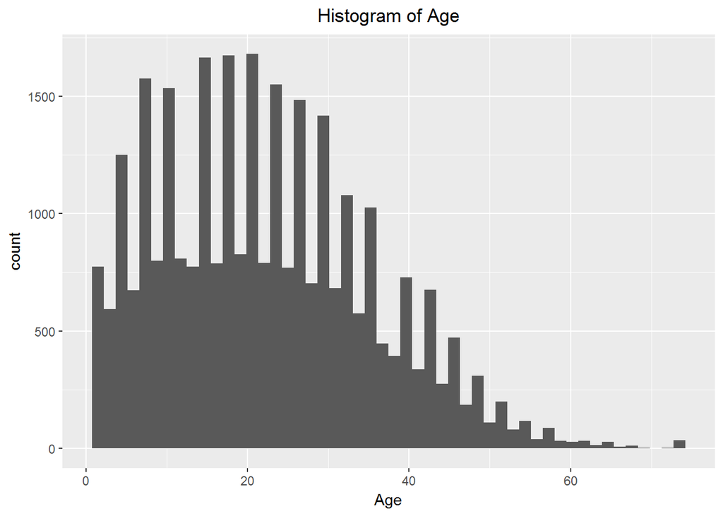

```r
# custom function to create the histogram
histogram <- function(data, colname) {
    no_of_unique <- nrow(unique(census_data_wo_missing[tolower(colname)]))
    g <- ggplot(census_data_wo_missing, aes(x = data)) +
                xlab(colname) +
                ggtitle(paste("Histogram of", colname, sep = " ")) +
                theme(plot.title = element_text(hjust = 0.5))
    if(no_of_unique < 50) {
        g + geom_histogram(bins = no_of_unique)
    }
    else if (no_of_unique >=50){
        g + geom_histogram(bins = 50)
    }

}

histogram(census_data_wo_missing$age, "Age")
```

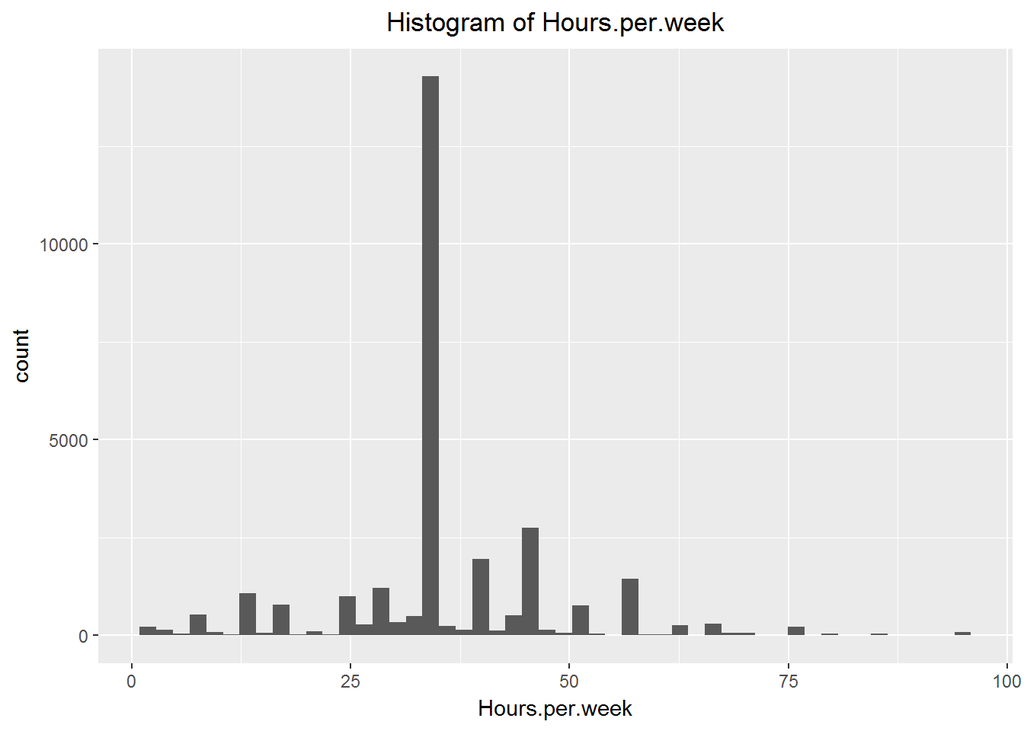

```r
histogram(census_data_wo_missing$hours.per.week, "Hours.per.week")
```

2. (4 points) For each of the two variables, create 2 histograms as part of the same figure (stacked side-by-side or one on top of another). In one histogram, only consider data samples with the class variable is “> 50k”; in the other, only consider data samples where the class variables is “<= 50k”.

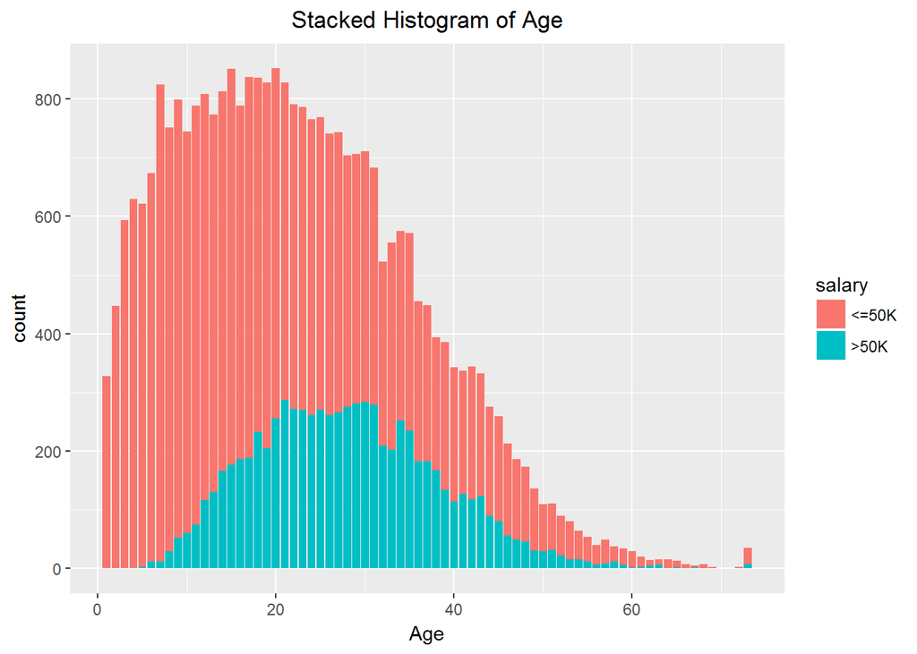

```r
# custom function to print stacked
# histogram based on salary
stacked_hist <- function(data, colname) {
    ggplot(census_data_wo_missing, aes(x = data, fill = salary)) +
        xlab(colname) +
        ggtitle(paste("Stacked Histogram of", colname, sep = " ")) +
        theme(plot.title = element_text(hjust = 0.5)) +
        geom_bar() # defaults to stacking
}

stacked_hist(census_data_wo_missing$age, "Age")
```

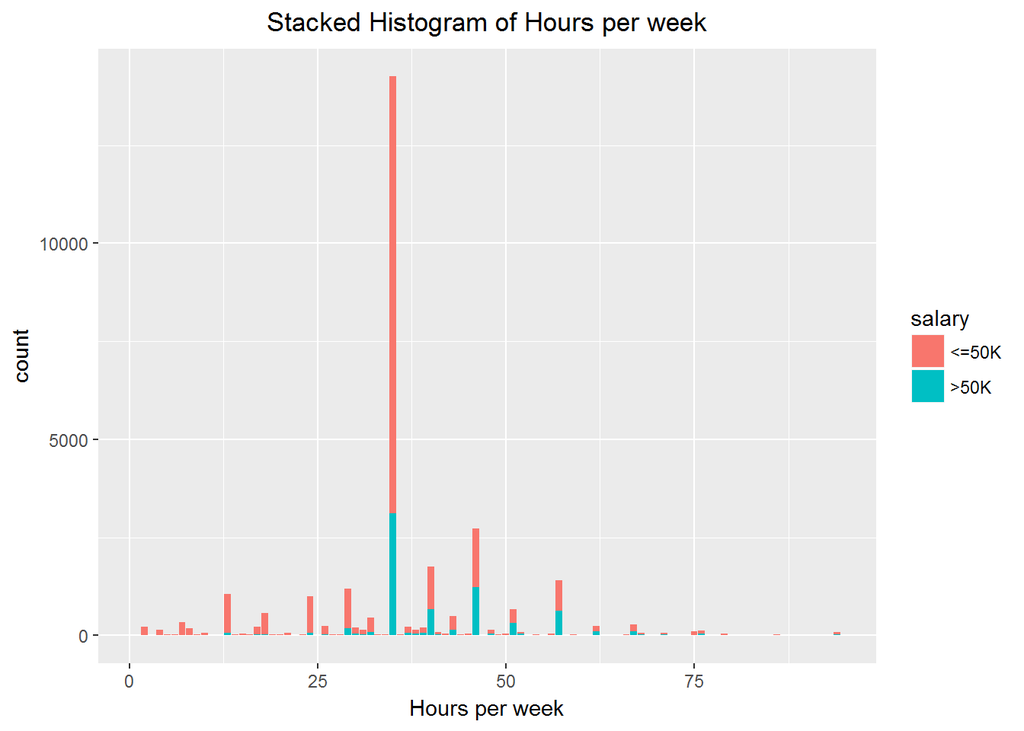

```r
stacked_hist(census_data_wo_missing$hours.per.week, "Hours per week")
```

3. (4 points) For each of the two variables, generate a figure with 2 boxplots side-by-side, with the two boxplots corresponding to samples for the two classes: “<= 50k” and “> 50k”.

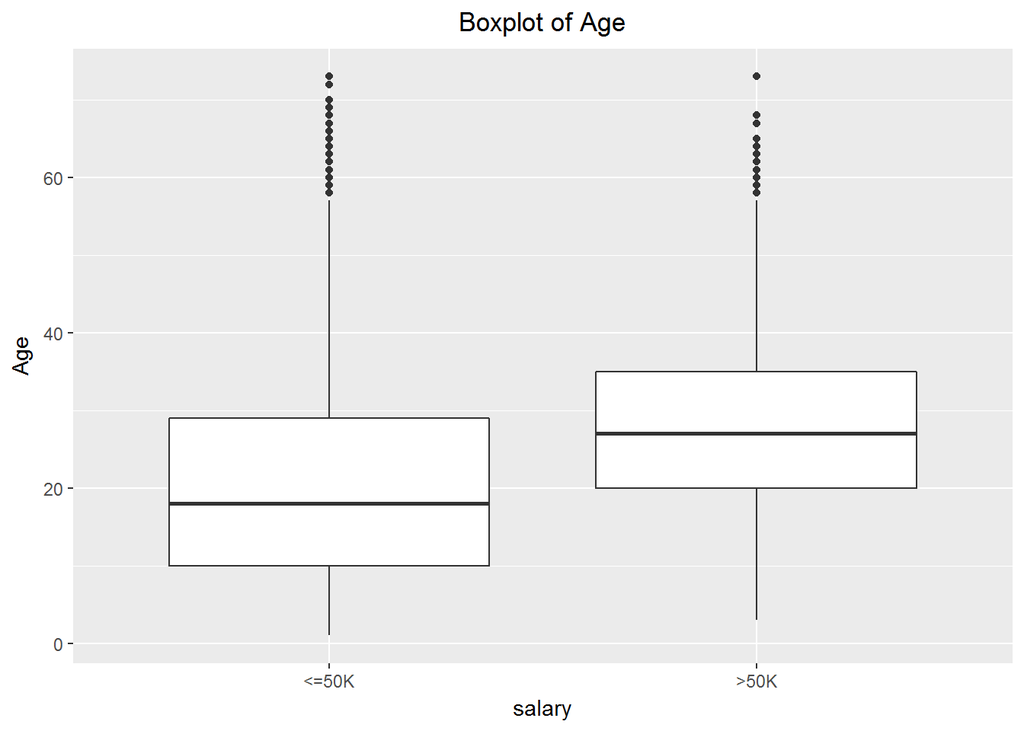

```r
# custom function to print stacked
# boxplot based on salary
stacked_boxplot <- function(data, colname) {
    ggplot(census_data_wo_missing, aes(x = salary, y = data)) +
        ylab(colname) +
        ggtitle(paste("Boxplot of", colname, sep = " ")) +
        theme(plot.title = element_text(hjust = 0.5)) +
        geom_boxplot() # defaults to stacking
}

stacked_boxplot(census_data_wo_missing$age, "Age")
```

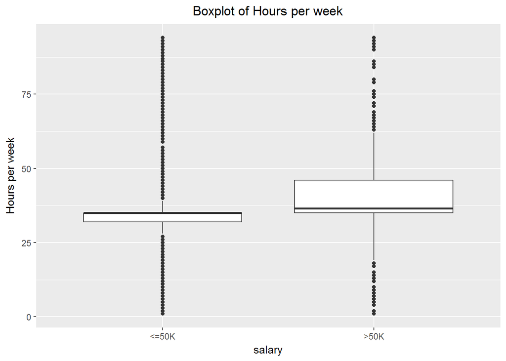

```r
stacked_boxplot(census_data_wo_missing$hours.per.week, "Hours per week")
```

#### Question 2 (e)

**Categorical Data**

For two of the categorical variables (not including the class variable, last column), answer the following questions.

I am choosing the following two variables

- Sex
- Race
1. (4 points) For each of the two variables, generate a bar plot, where each bar corresponds to the number of unique values. Include, missing values as a possible value in the plot.

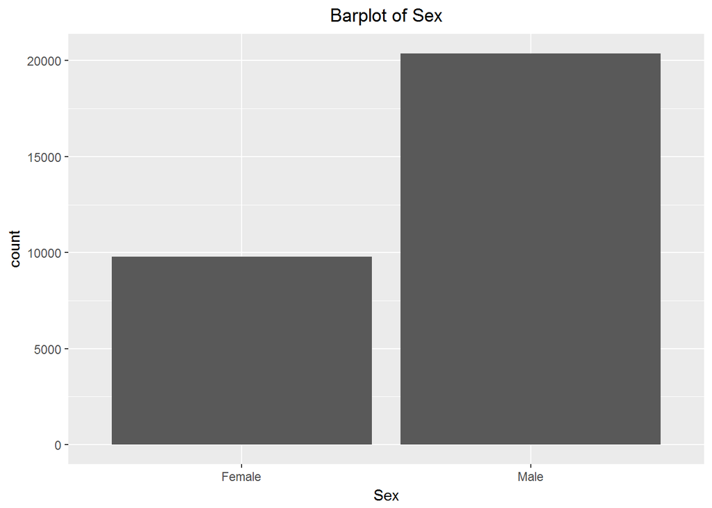

```r
# custom function to print stacked
# barplot based on salary
bar_plot <- function(data, colname) {
    ggplot(census_data_wo_missing, aes(x = data)) +
        xlab(colname) +
        ggtitle(paste("Barplot of", colname, sep = " ")) +
        theme(plot.title = element_text(hjust = 0.5)) +
        geom_bar() # defaults to stacking
}
bar_plot(census_data_wo_missing$sex, "Sex")
```

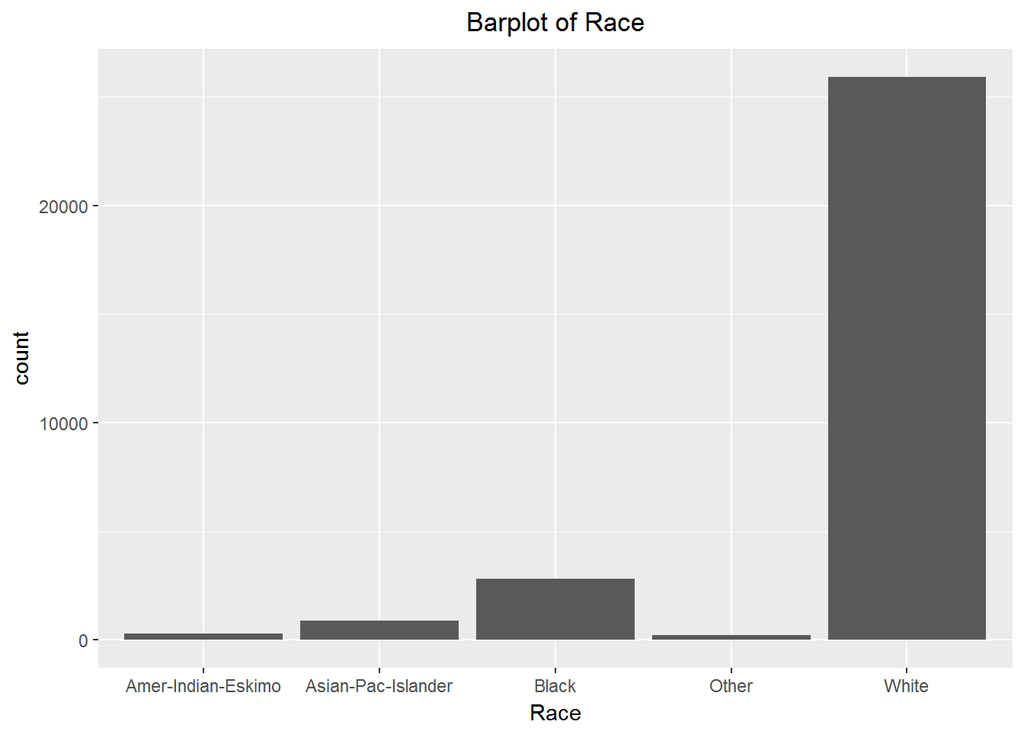

```r
bar_plot(census_data_wo_missing$race, "Race")
```

2. (4 points) For each of the two variables, create 2 bar plots in a single figure (stacked one on top of the other). The top bar plot is for the data with the class “<= 50k” and the bottom plot is for data with the class “> 50k”.

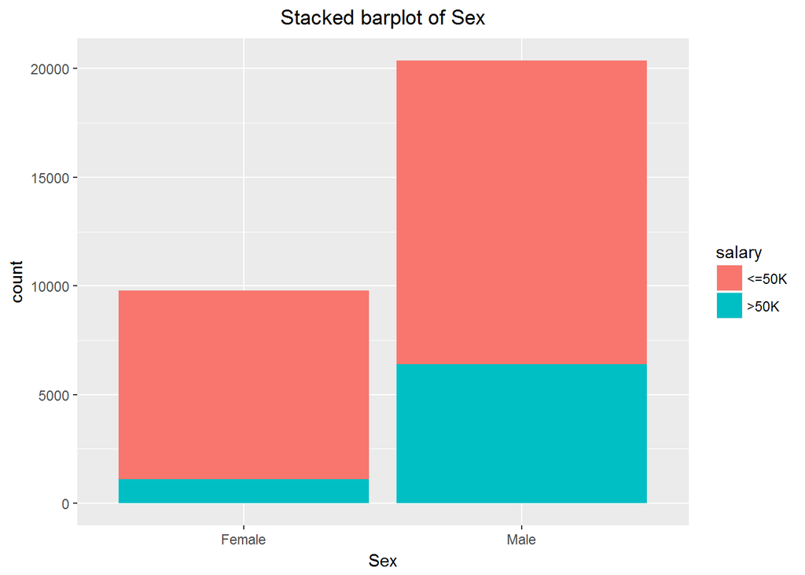

```r
# custom function to print stacked
# barplot based on salary
Stacked_barplot <- function(data, colname) {
    ggplot(census_data_wo_missing, aes(x = data, fill = salary)) +
        xlab(colname) +
        ggtitle(paste("Stacked barplot of", colname, sep = " ")) +
        theme(plot.title = element_text(hjust = 0.5)) +
        geom_bar() # defaults to stacking
}
Stacked_barplot(census_data_wo_missing$sex, "Sex")
```

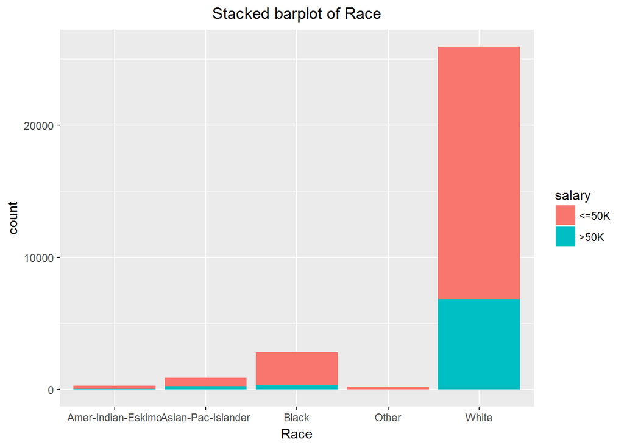

```r
Stacked_barplot(census_data_wo_missing$race, "Race")
```

3. (6 points) Describe what the plots have revealed about the data (2-4 sentences).
- It looks like there are more number of Male than Female in the dataset. People with salary less than 50k are more in both Male and female with Female population having more percent of less than 50k salary commpared to Male.
- When taking distribution of race of the people, there are lot of number of white people who have large percent of people with salary >50k. And at the same time, Black people being second on the list with number of people in the dataset, have very less percent of people with salary >50k.

#### Question 2 (f)

**Pairwise Analysis:**

1. (5 points) Pick a categorical variable, then explore how the variable changes with “Age”. Explore whether the variable you select appears to depend on age, or whether it is independent of age. Clearly indicate what evidence there is to support your conclusion.

Here I am picking **Sex** as the categorical variable which I am going to explore it with age First lets see the graph.

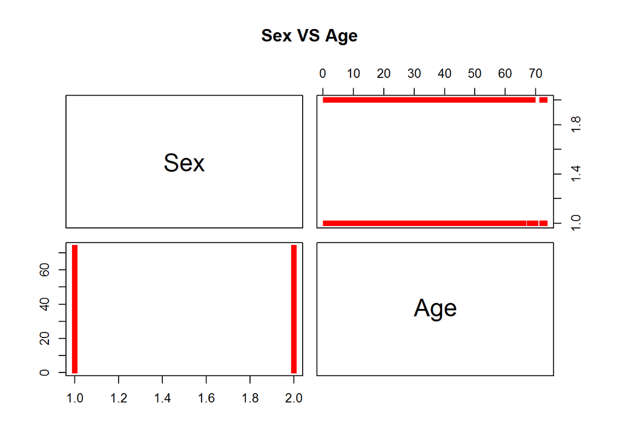

```
## [1] 0.08201348
```

```r
# custome fuction to do pairwise analysis
# from the graph
pairwise <- function(colValues1, colValues2, label1, label2) {
        pairs(cbind(as.numeric(colValues1), as.numeric(colValues2)),
              labels = c(label1, label2),
              main = paste(label1, label2, sep = " VS "), pch = 15, col = "red")
        print(cor(as.numeric(colValues1), colValues2))
}
pairwise(census_data_wo_missing$sex, census_data_wo_missing$age,
         "Sex", "Age")
```

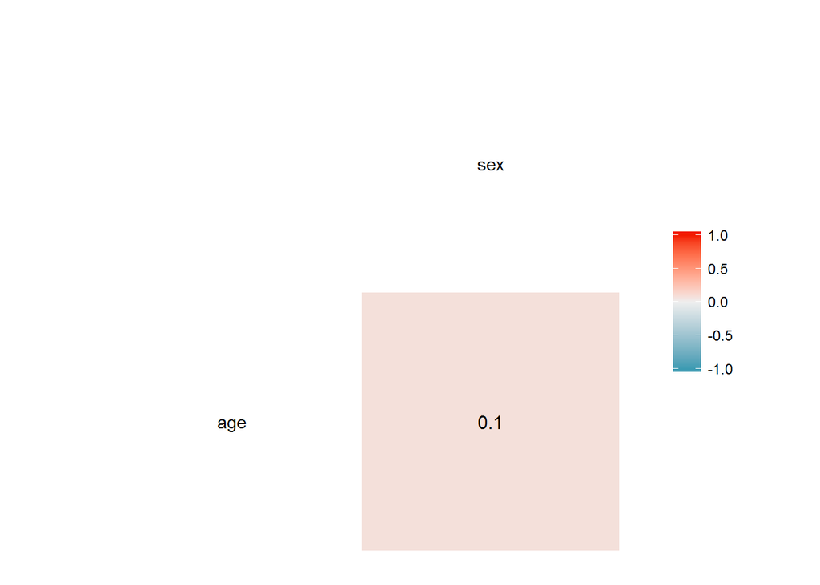

```r
# Prepare some data
df <- census_data_wo_missing[, c(1, 10)]
df$sex <- as.numeric(df$sex)
# Correlation plot
ggcorr(df, palette = "RdBu", label = TRUE)
```

**From the above two graph, we can say that there no dependancy between age and sex. From the first graph, there is not much significant relationship between sex and age and also second graph which showing the correlation between them as 0.1 which is very less. Correlation is higher if value is much away from 0.**

2. (5 points) Pick any two numeric variables, and explore whether or not they depend on each other, i.e., are they independent or not? Clearly indicate what evidence there is to support your conclusion.

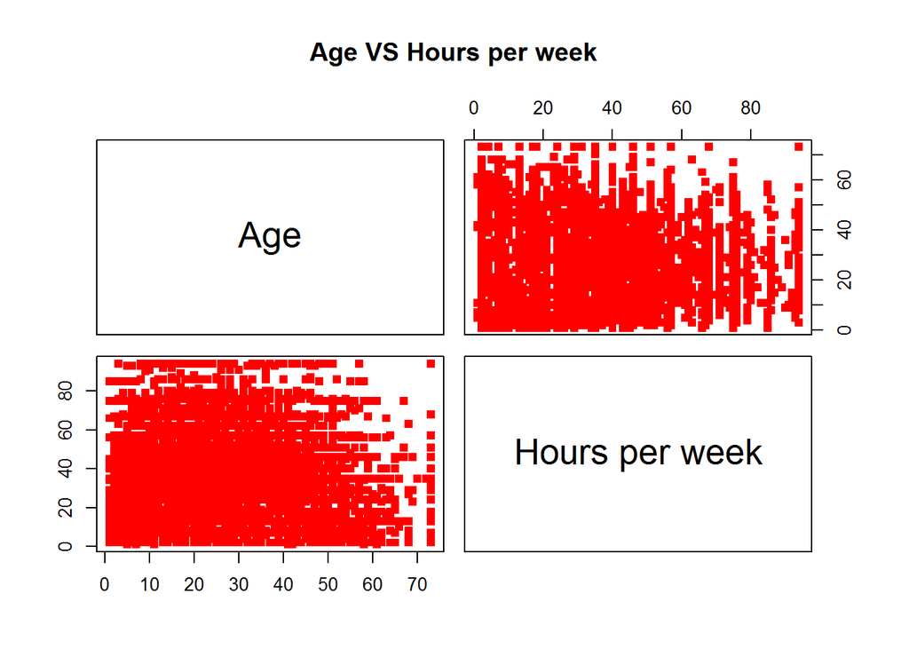

```
## [1] 0.1138805
```

```r
pairwise(census_data_wo_missing$age, census_data_wo_missing$hours.per.week,
         "Age", "Hours per week")
```

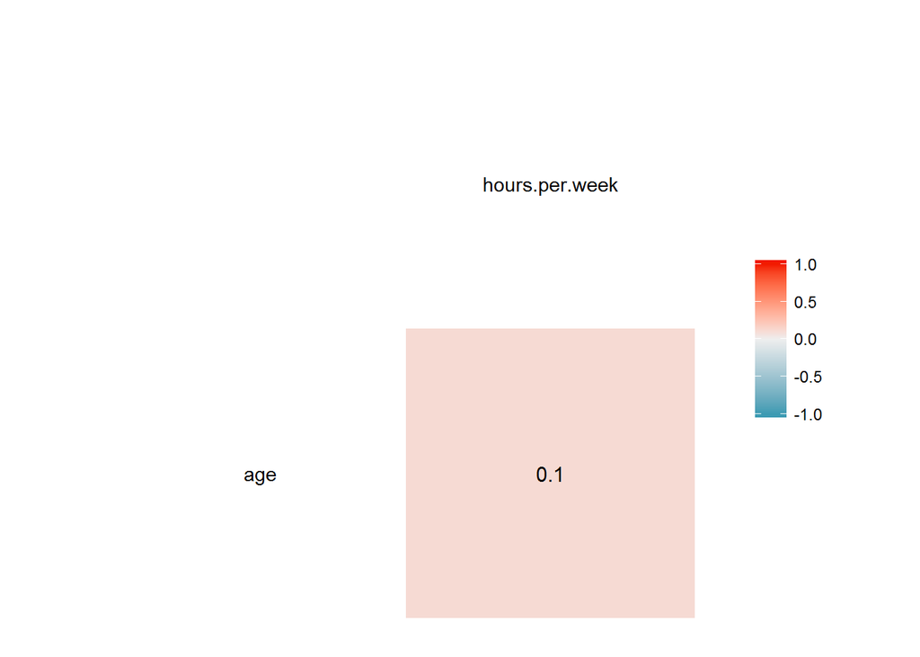

```r
# Prepare some data
df <- census_data_wo_missing[, c(1, 13)]

# Correlation plot
ggcorr(df, palette = "RdBu", label = TRUE)
```

**Here also, there is no kind od discrete pattern between Age and hours per week on the pairwise plot. And the correlation matrix plot also says there is no correlation between them. Thus, there is no relationship evident between them.**

## Question 3

### Automotive Data

Consider the data set provided: Auto.csv that describes several aspects of many cars.

1 Answer the following questions:

#### Question 3 (a)

(3 points) Which of the variables are quantitative and which are qualitative? (Use column names)

```r
# reading the data from csv file
auto_data <- read.csv("data/auto.csv")

# removing missing values
for(colname in colnames(auto_data)) {
    auto_data <- auto_data[auto_data[colname] != "?", ]
}

head(auto_data)
```

```
##   mpg cylinders displacement horsepower weight acceleration year origin
## 1  18         8          307        130   3504         12.0   70      1
## 2  15         8          350        165   3693         11.5   70      1
## 3  18         8          318        150   3436         11.0   70      1
## 4  16         8          304        150   3433         12.0   70      1
## 5  17         8          302        140   3449         10.5   70      1
## 6  15         8          429        198   4341         10.0   70      1
##                        name
## 1 chevrolet chevelle malibu
## 2         buick skylark 320
## 3        plymouth satellite
## 4             amc rebel sst
## 5               ford torino
## 6          ford galaxie 500
```

```r
str(auto_data)
```

```
## 'data.frame':    392 obs. of  9 variables:
##  $ mpg         : num  18 15 18 16 17 15 14 14 14 15 ...
##  $ cylinders   : int  8 8 8 8 8 8 8 8 8 8 ...
##  $ displacement: num  307 350 318 304 302 429 454 440 455 390 ...
##  $ horsepower  : Factor w/ 94 levels "?","100","102",..: 17 35 29 29 24 42 47 46 48 40 ...
##  $ weight      : int  3504 3693 3436 3433 3449 4341 4354 4312 4425 3850 ...
##  $ acceleration: num  12 11.5 11 12 10.5 10 9 8.5 10 8.5 ...
##  $ year        : int  70 70 70 70 70 70 70 70 70 70 ...
##  $ origin      : int  1 1 1 1 1 1 1 1 1 1 ...
##  $ name        : Factor w/ 304 levels "amc ambassador brougham",..: 49 36 231 14 161 141 54 223 241 2 ...
```

```r
# Horsepower is numeric
auto_data$horsepower <- as.numeric(auto_data$horsepower)
```

### Quantitative variables

- mpg
- displacement
- horsepower
- weight
- acceleration

### Quanlitative variables

- cylinders
- year
- origin
- name

#### Question 3 (b)

(10 points) For each of the quantitative variables, calculate and report in a table the mean, median, mode, and range. For mode you will need to write your own function to perform the calculation.

```r
# Subsetting the quantitative varibles
quanti_auto_data <- auto_data[c("mpg", "displacement", "horsepower", "weight", "acceleration")]

# custome function for finding mode and range
Mode <- function(x) {
  ux <- unique(x)
  ux[which.max(tabulate(match(x, ux)))]
}

Range <- function(x) {
    paste(min(x), max(x), sep = " | ")
}

# computing mean meadian mode range
mean_list <- lapply(quanti_auto_data, mean)
median_list <- lapply(quanti_auto_data, median)
mode_list <- lapply(quanti_auto_data, Mode)
range_list <- lapply(quanti_auto_data, Range)

# forming the table
cbind(Mean = mean_list, Median = median_list, Mode = mode_list, Range = range_list)
```

```
##              Mean     Median Mode Range
## mpg          23.44592 22.75  13   "9 | 46.6"
## displacement 194.412  151    97   "68 | 455"
## horsepower   52.16071 62     29   "2 | 94"
## weight       2977.584 2803.5 2130 "1613 | 5140"
## acceleration 15.54133 15.5   14.5 "8 | 24.8"
```

**For parts (c)-(e), only consider the variables displacement-DS and horsepower-HP.**

#### Question 3 (c)

(3 points) Calculate the first quartile, Q1, 37th, and 89th percentile of DS and HP.

**Displacement**

```r
# custome function for calculation
cust_percentile <- function(data) {
    percentiles <- quantile(data, c(0.25, 0.37, 0.89))
    print(paste("First quartile is", percentiles[1], sep = " "))
    print(paste("37th percentile is", percentiles[2], sep = " "))
    print(paste("89th  percentile is", percentiles[3], sep = " "))
}

cust_percentile(quanti_auto_data$displacement)
```

```
## [1] "First quartile is 105"
## [1] "37th percentile is 121"
## [1] "89th  percentile is 350"
```

**Horsepower**

```r
cust_percentile(quanti_auto_data$horsepower)
```

```
## [1] "First quartile is 26.75"
## [1] "37th percentile is 38.67"
## [1] "89th  percentile is 86"
```

#### Question 3 (d)

(4 points) Present the five-number summary of DS and HP as a table.

**Displacement**

```r
summary(quanti_auto_data$displacement)
```

```
##    Min. 1st Qu.  Median    Mean 3rd Qu.    Max.
##    68.0   105.0   151.0   194.4   275.8   455.0
```

**Horsepower**

```r
summary(quanti_auto_data$horsepower)
```

```
##    Min. 1st Qu.  Median    Mean 3rd Qu.    Max.
##    2.00   26.75   62.00   52.16   80.00   94.00
```

#### Question 3 (e)

(4 points) Draw the box plots for DS and HP

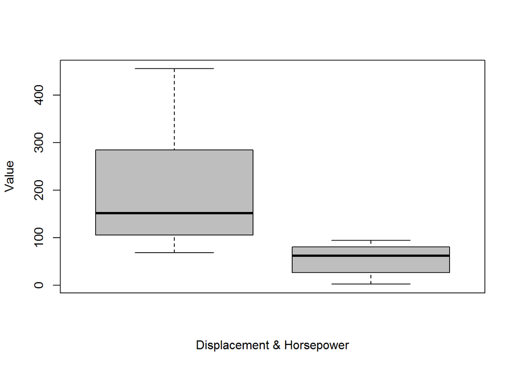

```r
# custom function to print stacked
# boxplot based on salary

boxplot(auto_data$displacement, auto_data$horsepower,
        col = "grey", xlab = "Displacement & Horsepower",
        ylab = "Value", xaxt = "n")
```

#### Question 3 (f)

(6 points) Investigate the relationship among different variables using scatterplots and other graphics utilities. Describe any interesting relationships found.

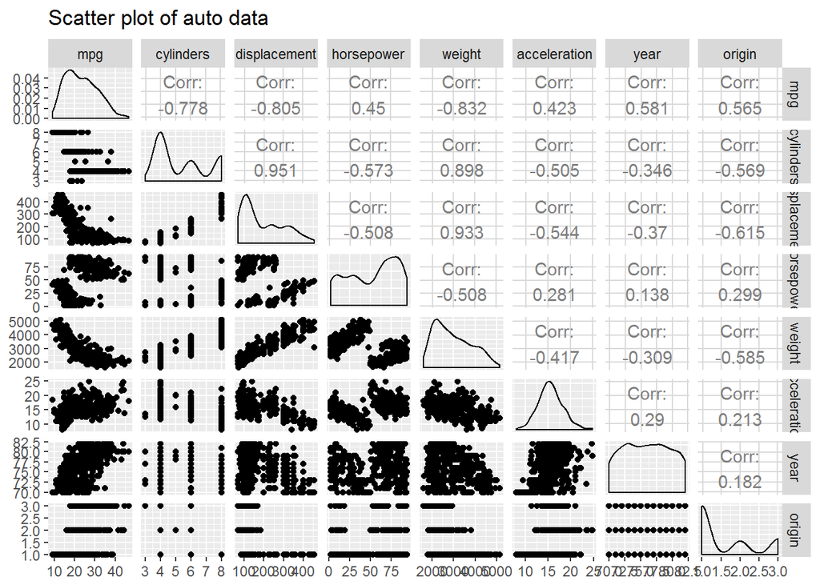

```r
ggpairs(auto_data[, -9], title = "Scatter plot of auto data")
```

From the graph it looks like the following relationship has strong positive correlation

- Displacement vs cylinder
- Displacement vs Weight
- mpg vs year
- mpg vs origin
- Cylinder vs weight

And the following has strong negative correlation

- mpg vs Weight
- mpg vs Displacement
- mpg vs Cylinder
- orgin vs Displacement
- Weight vs Origin
- Cylinder vs Horsepower

#### Question 3 (g)

(4 points) Let’s say we want to predict mpg using the other variables. What other variables would be most useful in this prediction task. Why?

It looks like mpg is continuous varible, thus using **regression analysis** would be a good option to predict it.

If you see the above the graph where the scatterplot matrix shows the correlation of those values, it is evident that mpg has the following correlation with other variables.

- Cylinder (-0.778)
- displacement (-0.805)
- horsepower (0.450)
- weight (-0.832)
- acceleration (0.423)
- year (0.581)
- origin (0.565)

By setting the cut off value for the variable selection at .5. And year and origin have nearly very close correlation values. Thus, it doesn’t have much of effect in reducing mean square error, thus it’s better to any one of those.

- Cylinder (-0.778)
- displacement (-0.805)
- weight (-0.832)
- year (0.581)

NOte: Though, here I have used correlation to do variable selection, inorder to have model which can have very less generalization error as possible, cross validation methodology has to be applied. This help us to identify the model which perform good on any data.

```r
## 75% of the sample size
smp_size <- floor(0.75 * nrow(auto_data))

## set the seed to make your partition reproductible
set.seed(123)
train_ind <- sample(seq_len(nrow(auto_data)), size = smp_size)

train <- auto_data[train_ind, ]
test <- auto_data[-train_ind, ]

# training the model
model <- lm(mpg ~ cylinders + displacement +weight+year, data = train)
summary(model)
```

```
##
## Call:
## lm(formula = mpg ~ cylinders + displacement + weight + year,
##     data = train)
##
## Residuals:
##     Min      1Q  Median      3Q     Max
## -8.8795 -2.3381  0.0417  2.0655 12.5627
##
## Coefficients:
##                Estimate Std. Error t value Pr(>|t|)
## (Intercept)  -16.137783   4.914528  -3.284  0.00115 **
## cylinders     -0.293860   0.377399  -0.779  0.43683
## displacement   0.006933   0.008221   0.843  0.39971
## weight        -0.006804   0.000717  -9.489  < 2e-16 ***
## year           0.792684   0.061050  12.984  < 2e-16 ***
## ---
## Signif. codes:  0 '***' 0.001 '**' 0.01 '*' 0.05 '.' 0.1 ' ' 1
##
## Residual standard error: 3.446 on 289 degrees of freedom
## Multiple R-squared:  0.8153, Adjusted R-squared:  0.8127
## F-statistic: 318.9 on 4 and 289 DF,  p-value: < 2.2e-16
```

```r
# crossvalidating
# K-fold cross-validation
cv.lm(test, model, 3) # 3 fold cross-validation
```

```
## Analysis of Variance Table
##
## Response: mpg
##              Df Sum Sq Mean Sq F value  Pr(>F)
## cylinders     1   3125    3125  266.70 < 2e-16 ***
## displacement  1     85      85    7.26  0.0084 **
## weight        1    314     314   26.84 1.3e-06 ***
## year          1    596     596   50.85 2.1e-10 ***
## Residuals    93   1090      12
## ---
## Signif. codes:  0 '***' 0.001 '**' 0.01 '*' 0.05 '.' 0.1 ' ' 1
```

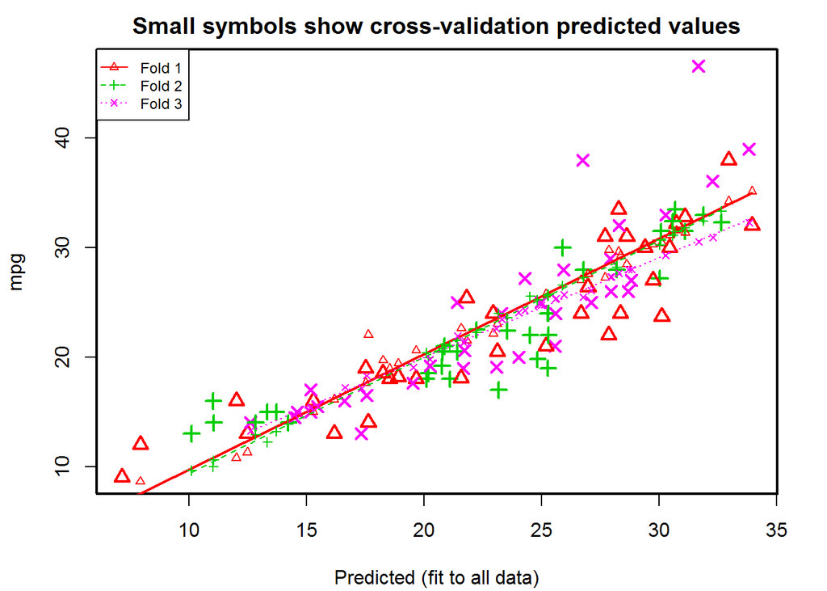

```
##
## fold 1
## Observations in test set: 32
##                 4    14    22   29    37    46    49    54    74    91
## Predicted   15.30 17.63 22.94 7.16 17.52 19.66 18.54 27.69 12.48  7.94
## cvpred      14.99 22.03 22.16 4.48 17.63 20.61 18.95 27.27 11.31  8.63
## mpg         16.00 14.00 24.00 9.00 19.00 18.00 18.00 31.00 13.00 12.00
## CV residual  1.01 -8.03  1.84 4.52  1.37 -2.61 -0.95  3.73  1.69  3.37
##               110   119   130  159   209    218   240   247   254   262
## Predicted   25.18 26.68 28.62 12.0 16.19 29.395 30.45 31.10 23.11 21.58
## cvpred      25.74 27.03 28.48 10.8 16.11 30.134 31.12 31.39 23.06 22.62
## mpg         21.00 24.00 31.00 16.0 13.00 30.000 30.00 32.80 20.50 18.10
## CV residual -4.74 -3.03  2.52  5.2 -3.11 -0.134 -1.12  1.41 -2.56 -4.52
##               289   293  298   309   315    322  335   369   374   378
## Predicted   18.90 18.26 21.8 28.28 26.97 30.729 30.1 29.73 28.35 32.95
## cvpred      19.42 19.71 21.5 29.62 27.58 31.576 30.4 30.27 29.23 34.24
## mpg         18.20 18.50 25.4 33.50 26.40 32.200 23.7 27.00 24.00 38.00
## CV residual -1.22 -1.21  3.9  3.88 -1.18  0.624 -6.7 -3.27 -5.23  3.76
##               384   389
## Predicted   33.94 27.86
## cvpred      35.14 29.76
## mpg         32.00 22.00
## CV residual -3.14 -7.76
##
## Sum of squares = 434    Mean square = 13.6    n = 32
##
## fold 2
## Observations in test set: 33
##                 2     12    13   17    53    58    72    79   100   111
## Predicted   13.72 14.232 13.34 20.1 25.88 25.25 25.27 20.86 21.09 25.29
## cvpred      13.19 13.831 12.22 20.4 26.55 25.62 25.66 21.15 21.03 25.73
## mpg         15.00 14.000 15.00 18.0 30.00 24.00 19.00 21.00 18.00 22.00
## CV residual  1.81  0.169  2.78 -2.4  3.45 -1.62 -6.66 -0.15 -3.03 -3.73
##               138   141  150   157   160    183    195    217   221    227
## Predicted   10.11 12.83 25.3 11.04 11.05 26.779 22.237 30.071 30.68 20.780
## cvpred       9.63 12.91 25.6  9.97 10.57 27.269 22.213 30.682 31.45 20.778
## mpg         13.00 14.00 24.0 16.00 14.00 28.000 22.500 31.500 33.50 20.500
## CV residual  3.37  1.09 -1.6  6.03  3.43  0.731  0.287  0.818  2.05 -0.278
##               229   242   253    257  276    279   282    314   338   339
## Predicted   20.17 24.51 20.77 21.418 23.2 31.081 24.82 28.186 30.57 30.02
```

[output cut: 24 more lines]

```
## Predicted   15.4858 28.69 32.27 21.738 19.54 20.257 24.29 23.1 31.7 33.82
## cvpred      15.5295 27.99 30.95 21.461 19.06 19.787 24.27 22.6 30.5 32.27
## mpg         15.5000 26.00 36.10 20.600 17.60 19.200 27.20 19.1 46.6 39.00
## CV residual -0.0295 -1.99  5.15 -0.861 -1.46 -0.587  2.93 -3.5 16.1  6.73
##              386  387    393
## Predicted   27.1 26.8 28.824
## cvpred      26.1 25.5 27.998
## mpg         25.0 38.0 27.000
## CV residual -1.1 12.5 -0.998
##
## Sum of squares = 638    Mean square = 19.3    n = 33
##
## Overall (Sum over all 33 folds)
##   ms
## 13.8
```

## Question 4

### Sports Data

The use of data analysis in sports is becoming increasing more common (and a high profit business). Interest in this analysis grew substantially with the publishing of the book Moneyball (and the subsequent movie). Statistical analysis has spread to many other sports including basketball, football (both American and soccer), tennis, and many others.

#### Question 4 (a)

**Tennis Data**

For example, see the following articles on data analysis in tennis:

- [James Murphy Shares Remixes Made With Tennis Data Album, Pitchfork](http://pitchfork.com/news/57887-james-murphy-shares-remixes-made-with-tennis-data-album/)
- [Despite Advanced Stats, Tennis Has a Data Problem, Wall Street Journal](http://blogs.wsj.com/dailyfix/2013/09/07/despite-advanced-stats-tennis-has-a-data-problem/)
- [Why Tennis So Far Behind Other Sports in Data Analytics?](http://www.forbes.com/forbes/welcome/?toURL=http://www.forbes.com/sites/jimpagels/2015/03/03/why-is-tennis-so-far-behind-other-sports-in-data-analytics/&refURL=&referrer=#1d87b1242831) , Forbes
- [US Open 2015: Advanced Analytics in Tennis Takes a Minor Step Forward with IBM’s SlamTracker,](http://www.ibtimes.com/us-open-2015-advanced-analytics-tennis-takes-minor-step-forward-ibms-slamtracker-2087873) IBTimes

Recenting a crowd-sourcing solution has been used to chart tennis match statistics. This project Match Charting Project has seen growth in data collected to over 2500 matches. The data is housed at Github tennis MatchChartingProject. For this analysis, you will focus on some basic statistics that can be calculated from this data set. You will only need the files: charting-m-matches.csv, charting-m-stats-Overview.csv, charting-w-matches.csv, and charting-w-stats-Overview.csv

Answer the following questions:

1. (16 points) For both the Men’s and Women’s tours, consider only matches at the four Grand Slams:
- Australian Open
- French Open
- Wimbledon
- US Open

from 2011 - present. List the top 5 men and women with the most Aces/match along with this value.

```r
# reading the data
charting_m_matches <- read.csv("data/tennis_match_charting/charting-m-matches.csv")
charting_m_stats_Overview <- read.csv("data/tennis_match_charting/charting-m-stats-Overview.csv")
charting_w_matches <- read.csv("data/tennis_match_charting/charting-w-matches.csv")
charting_w_stats_Overview <- read.csv("data/tennis_match_charting/charting-w-stats-Overview.csv")

head(charting_m_matches)
```

```
##                                                            match_id
## 1 20160611-M-Caltanissetta_CH-SF-Alessandro_Giannessi-Paolo_Lorenzi
## 2             20160605-M-Roland_Garros-F-Andy_Murray-Novak_Djokovic
## 3        20160603-M-Roland_Garros-SF-Stanislas_Wawrinka-Andy_Murray
## 4          20160603-M-Roland_Garros-SF-Novak_Djokovic-Dominic_Thiem
## 5       20160528-M-Roland_Garros-R32-Alexander_Zverev-Dominic_Thiem
## 6                  20160521-M-Nice-F-Dominic_Thiem-Alexander_Zverev
##               Player.1         Player.2 Pl.1.hand Pl.2.hand Gender
## 1 Alessandro Giannessi    Paolo Lorenzi         L         R      M
## 2          Andy Murray   Novak Djokovic         R         R      M
## 3   Stanislas Wawrinka      Andy Murray         R         R      M
## 4       Novak Djokovic    Dominic Thiem         R         R      M
## 5     Alexander Zverev    Dominic Thiem         R         R      M
## 6        Dominic Thiem Alexander Zverev         R         R      M
##       Date       Tournament Round  Time                 Court Surface
## 1 20160611 Caltanissetta CH    SF                      Centro    Clay
## 2 20160605    Roland Garros     F 15:00              Chatrier    Clay
## 3 20160603    Roland Garros    SF           Philippe Chatrier    Clay
## 4 20160603    Roland Garros    SF             Suzanne Lenglen    Clay
## 5 20160528    Roland Garros   R32       Suzanne Lenglen Court    Clay
## 6 20160521             Nice     F                      Centre    Clay
##             Umpire Best.of Final.TB.   Charted.by
## 1                        3         1 jeffsackmann
## 2  Damien Dumusois       5         0 jeffsackmann
## 3     Carlos Ramos       5         0        Edged
## 4 James Keothavong       5         0        Edged
## 5                        5         0        Edged
## 6    Pierre Bacchi       3         1 jeffsackmann
```

```r
head(charting_m_stats_Overview)
```

```
##                                                       match_id player
## 1 19751219-M-Davis_Cup_World_Group_F-RR-Bjorn_Borg-Jiri_Hrebec      1
## 2 19751219-M-Davis_Cup_World_Group_F-RR-Bjorn_Borg-Jiri_Hrebec      2
## 3 19751219-M-Davis_Cup_World_Group_F-RR-Bjorn_Borg-Jiri_Hrebec      1
## 4 19751219-M-Davis_Cup_World_Group_F-RR-Bjorn_Borg-Jiri_Hrebec      2
## 5 19751219-M-Davis_Cup_World_Group_F-RR-Bjorn_Borg-Jiri_Hrebec      1
## 6 19751219-M-Davis_Cup_World_Group_F-RR-Bjorn_Borg-Jiri_Hrebec      2
##     set serve_pts aces dfs first_in first_won second_in second_won bk_pts
## 1 Total        69    2   1       32        25        37         21      5
## 2 Total        63    2   2       41        20        22          7     12
## 3     1        26    2   0       15        10        11          6      2
## 4     1        18    0   0       11         3         7          2      3
## 5     2        24    0   0       10         9        14          8      1
## 6     2        26    2   1       18        12         8          4      4
##   bp_saved return_pts return_pts_won winners winners_fh winners_bh
## 1        4         63             36      28         10         16
## 2        4         69             23      14          8          4
## 3        1         18             13      10          3          5
## 4        0         26             10       4          2          2
## 5        1         26             10       9          3          6
## 6        2         24              7       8          5          1
##   unforced unforced_fh unforced_bh
## 1       16           6           9
## 2       26          15           9
## 3        6           2           4
## 4       10           7           3
## 5        6           2           4
## 6        8           4           3
```

```r
head(charting_w_matches)
```

```
##                                                             match_id
## 1                   20160611-W-Nottingham-QF-Tara_Moore-Saisai_Zheng
## 2      20160610-W-sHertogenbosch-QF-Viktorija_Golubic-Belinda_Bencic
## 3        20160604-W-Roland_Garros-F-Serena_Williams-Garbine_Muguruza
## 4          20160602-W-Roland_Garros-QF-Kiki_Bertens-Timea_Bacsinszky
## 5             20160601-W-Roland_Garros-R16-Madison_Keys-Kiki_Bertens
## 6 20160601-W-Roland_Garros-R16-Carla_Suarez_Navarro-Yulia_Putintseva
##               Player.1         Player.2 Pl.1.hand Pl.2.hand Gender
## 1           Tara Moore     Saisai Zheng         R         R      W
## 2    Viktorija Golubic   Belinda Bencic         R         R      W
## 3      Serena Williams Garbine Muguruza         R         R      W
## 4         Kiki Bertens Timea Bacsinszky         R         R      W
## 5         Madison Keys     Kiki Bertens         R         R      W
## 6 Carla Suarez Navarro Yulia Putintseva         R         R      W
##       Date     Tournament Round  Time    Court Surface             Umpire
## 1 20160611     Nottingham    QF         Centre   Grass Paula Vieira Souza
## 2 20160610 sHertogenbosch    QF         Centre   Grass     Felix Torralba
## 3 20160604  Roland Garros     F 15:00 Chatrier    Clay       Pascal Maria
## 4 20160602  Roland Garros    QF                   Clay  Marijana Veljovic
## 5 20160601  Roland Garros   R16              1    Clay
## 6 20160601  Roland Garros   R16              2    Clay    Damien Dumusois
##   Best.of Final.TB.   Charted.by
## 1       3         1 jeffsackmann
## 2       3         1 jeffsackmann
## 3       3         0 jeffsackmann
## 4       3         0 jeffsackmann
## 5       3         0 jeffsackmann
## 6       3         0 jeffsackmann
```

```r
head(charting_w_stats_Overview)
```

```
##                                                     match_id player   set
## 1 20070901-W-US_Open-R32-Agnieszka_Radwanska-Maria_Sharapova      1 Total
## 2 20070901-W-US_Open-R32-Agnieszka_Radwanska-Maria_Sharapova      2 Total
## 3 20070901-W-US_Open-R32-Agnieszka_Radwanska-Maria_Sharapova      1     1
## 4 20070901-W-US_Open-R32-Agnieszka_Radwanska-Maria_Sharapova      2     1
## 5 20070901-W-US_Open-R32-Agnieszka_Radwanska-Maria_Sharapova      1     2
## 6 20070901-W-US_Open-R32-Agnieszka_Radwanska-Maria_Sharapova      2     2
##   serve_pts aces dfs first_in first_won second_in second_won bk_pts
## 1        82    1   2       46        24        36         19     13
## 2        76    2  11       50        33        26          6     13
## 3        37    1   0       21        10        16         11      8
## 4        29    2   4       19        13        10          2      4
## 5        24    0   2       14         7        10          2      4
## 6        19    0   4       13        11         6          2      1
##   bp_saved return_pts return_pts_won winners winners_fh winners_bh
## 1        7         76             37      18         11          5
## 2        7         82             39      30         12         13
## 3        6         29             14       8          3          3
## 4        1         37             16      12          2          6
## 5        1         19              6       5          4          1
## 6        1         24             15      11          5          6
##   unforced unforced_fh unforced_bh
## 1       33          13          18
## 2       53          25          17
## 3       11           5           6
## 4       23          10           9
## 5       11           3           6
## 6        9           2           3
```

#### Top 5 Men and women with most aces

```r
# mentioned tour vector
mentioned_tournaments <- c("Australian Open", "French Open", "Wimbledon", "US Open")

# Function to get year
get_year <- function(data) {
    as.numeric(substring(data, 1, 4))
}

# function to get specified tour data after 2011
prep_data <- function(matches_data, stats_data) {
    mentioned_tour_matches <- matches_data[matches_data$Tournament == "Australian Open" | matches_data$Tournament == "French Open" | matches_data$Tournament == "Wimbledon" | matches_data$Tournament == "US Open",]
    mentioned_tour_matches$year <- get_year(mentioned_tour_matches$Date)
    matches_after_2011 <- mentioned_tour_matches[mentioned_tour_matches$year >= 2011, ]
    merge(matches_after_2011, stats_data, by = "match_id")
}


# function to find top five
top5_aces <- function(matches_data, stats_data) {
    merged_data <- prep_data(matches_data, stats_data)
    final_data <- aggregate(merged_data$aces, list(match_id = merged_data$match_id,
                                    player1 = as.character(merged_data$Player.1),
                                    player2 = as.character(merged_data$Player.2),
                                    player = merged_data$player), mean)
    final_data$player_name  <- ifelse(final_data$player == 1, final_data$player1, final_data$player2)
    sorted_data <- final_data[order(final_data$x, decreasing = TRUE), ]
    result <- sorted_data[1:5, c(6, 5)]
    names(result) <- c("Player Name", "No. of Aces/Matches")
    result
}

top5_aces(charting_m_matches, charting_m_stats_Overview)
```

```
##           Player Name No. of Aces/Matches
## 67       Nick Kyrgios                14.8
## 15       Nick Kyrgios                13.2
## 122      Ivo Karlovic                11.6
## 16      Tomas Berdych                10.0
## 37  Kenny De Schepper                10.0
```

```r
top5_aces(charting_w_matches, charting_w_stats_Overview)
```

```
##           Player Name No. of Aces/Matches
## 284 Kristyna Pliskova                15.5
## 30    Maria Sharapova                14.0
## 342   Serena Williams                12.0
## 80    Coco Vandeweghe                10.0
## 341   Serena Williams                10.0
```

2. (16 points) For both the Men’s and Women’s tours in 2015, determine the top 5 men and women who have at least 5 matches charted with the highest break points saved percentage: Num. Break Points Saved / Num. of Break Points = bkptsbpsaved

#### Top 5 Men and women with most Break point percent

```r
# function to get specified tour data after 2015
# with player those who p;ayed atleast 5 matches
prep_data_2 <- function(matches_data, stats_data) {
    matches_data$year <- get_year(matches_data$Date)
    matches_2015 <- matches_data[matches_data$year == 2015, ]
    player1 <- as.data.frame(table(matches_2015$Player.1))
    player2 <- as.data.frame(table(matches_2015$Player.2))
    binded_data <- rbind(player1, player2)
    aggregate_data <- aggregate(binded_data$Freq, list(binded_data$Var1), sum)
    player_matches <- aggregate_data[aggregate_data$x >= 5, ]
    players_morethan5 <- as.character(player_matches$Group.1)
    matches_2015_atleast_5 <- matches_2015[matches_2015$Player.1 %in% players_morethan5
                                           | matches_2015$Player.2 %in% players_morethan5, ]
    merge(matches_2015_atleast_5, stats_data, by = "match_id")
}


top5_bpsaved <- function(matches_data, stats_data) {
    merged_data <- prep_data_2(matches_data, stats_data)
    final_data <- aggregate(merged_data[, c("bp_saved", "bk_pts")], list(match_id = merged_data$match_id,
                                        player1 = as.character(merged_data$Player.1),
                                        player2 = as.character(merged_data$Player.2),
                                        player = merged_data$player), sum)
    final_data$player_name  <- ifelse(final_data$player == 1, final_data$player1, final_data$player2)
    result <- aggregate(final_data[, c("bp_saved", "bk_pts")], list(player_name = final_data$player_name),
                        sum)
    result$bp_saved_percent <- (as.numeric(result$bp_saved) / as.numeric(result$bk_pts)) * 100
    result <- result[order(-result$bp_saved_percent), c("player_name", "bp_saved_percent")]
    names(result) <- c("Player Name", "Bp saved percent (out of 100%)")
    result[1:5,]
}

top5_bpsaved(charting_m_matches, charting_m_stats_Overview)
```

```
##           Player Name Bp saved percent (out of 100%)
## 84         Mardy Fish                          100.0
## 96      Mischa Zverev                          100.0
## 116 Ricardas Berankis                          100.0
## 26      Denis Istomin                           92.3
## 57       Ivo Karlovic                           84.8
```

```r
top5_bpsaved(charting_w_matches, charting_w_stats_Overview)
```

```
##              Player Name Bp saved percent (out of 100%)
## 101           Ons Jabeur                           83.3
## 14  Anastasija Sevastova                           76.9
## 12            Ana Konjuh                           75.0
## 123  Svetlana Kuznetsova                           75.0
## 44    Ekaterina Makarova                           70.0
```

Other data sets exist charting similar information: [Github tennis slam pointbypoint.](https://github.com/JeffSackmann/tennis_slam_pointbypoint)

Tennis enthusiatics have even created challenges on data analysis and visualization [The Tennis Notebook - Storytelling Challenge](https://medium.com/the-tennis-notebook/tennis-data-storytelling-challenge-acf8a76558c8#.7l4mcutk9)

#### Question 4 (b)

(5 points (bonus)) Recreate one of the visualizations at [Tennis Visuals](http://tennisvisuals.com:8080/) using the data sets available above or create your own unique visualization of that tells a story about a match, a tournament, a career, a player, etc.

Here I have used interactive visualization where I am showing the serve point based on each surface. It can be embedded in any web page and can be interacted.

```r
men_merged_data <- merge(charting_m_matches, charting_m_stats_Overview, by = "match_id")
women_merged_data <- merge(charting_w_matches, charting_w_stats_Overview, by = "match_id")

surface_stats <- function(surface, serve_pts, men) {
    surface <- trimws(surface)
    surface[surface == ""] <- "Blank"
    surface[surface == "hard"] <- "Hard"
    surface[surface == "Hard Court"] <- "Hard"

    p <- plot_ly(
      x = surface,
      y = serve_pts,
      type = "bar"
    ) %>% layout(title = paste("Serve points on each Surface", men, sep = " - "))
    p
}

surface_stats(men_merged_data$Surface, men_merged_data$serve_pts, "Men")
```

[interactive chart not shown]

```r
surface_stats(women_merged_data$Surface, women_merged_data$serve_pts, "Women")
```

[interactive chart not shown]

** End of the assignment**